# Univariate Plots Section

## Density, Sugar and Alcohol Content

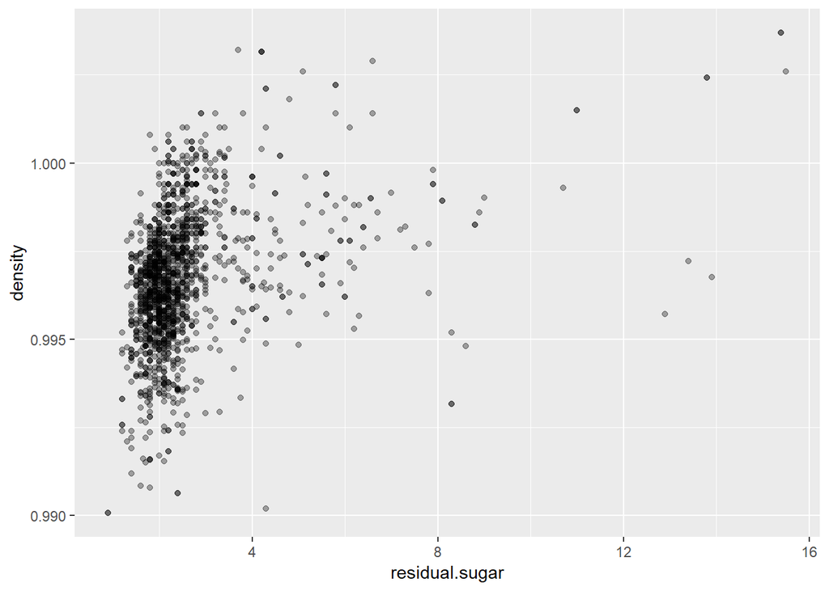

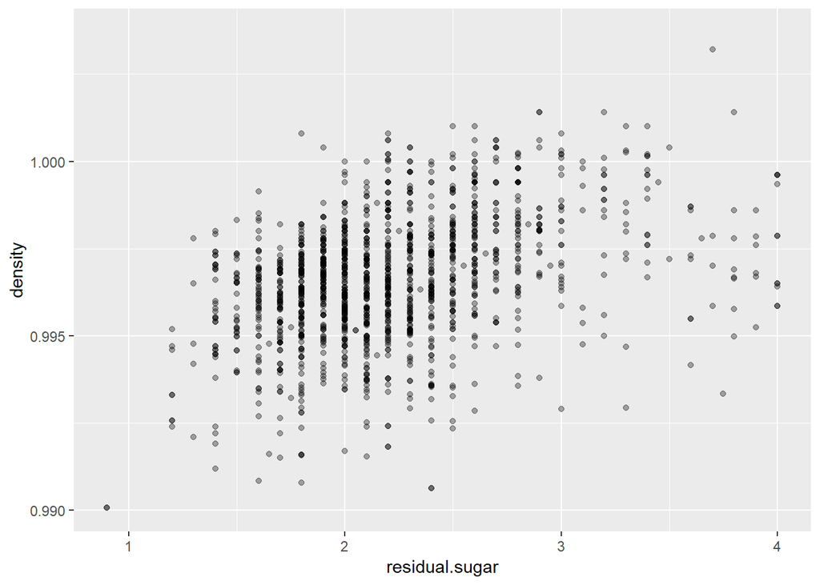

There is a positive correlation becasue Density seems to increase as residual sugar increases.

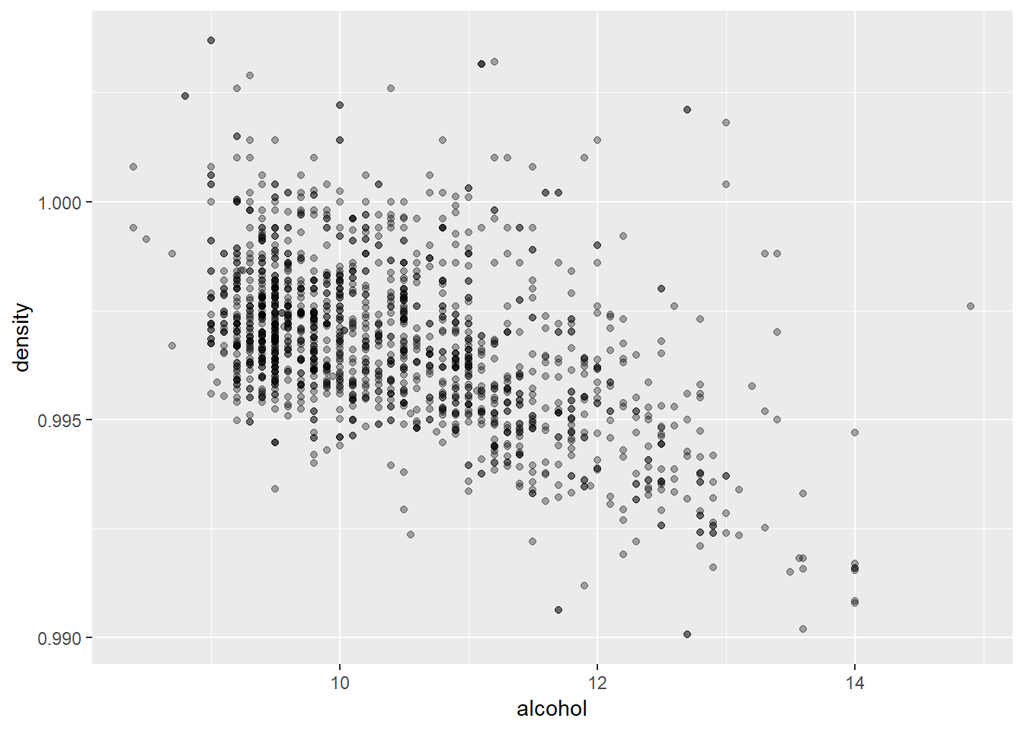

There is a negative correlation since Density seems to decrease as alcohol content increases.

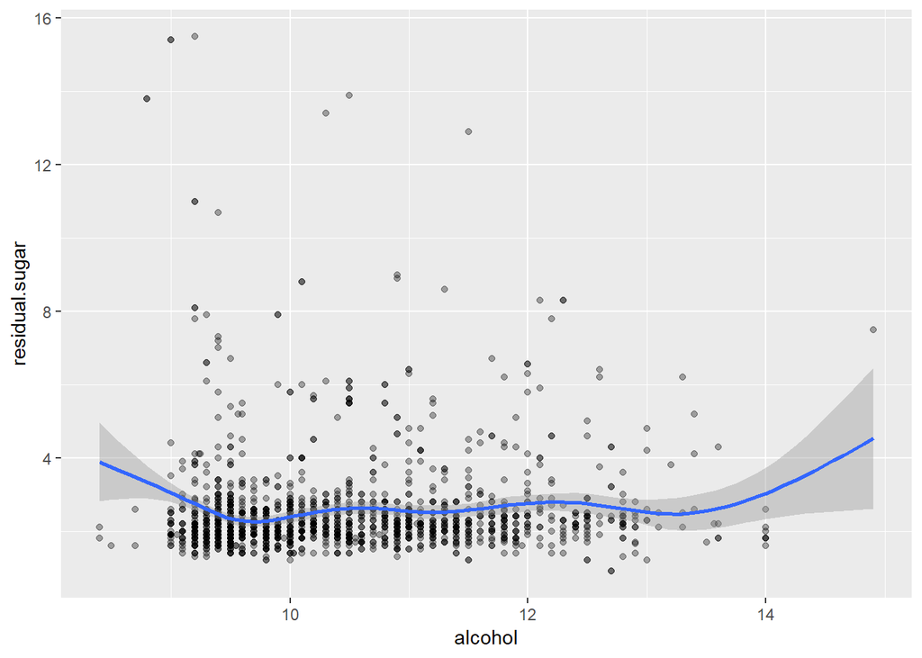

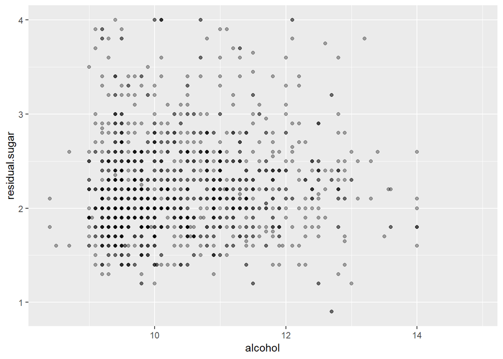

```
##
##  Pearson's product-moment correlation
##
## data:  residual.sugar and alcohol
## t = 1.6829, df = 1597, p-value = 0.09258
## alternative hypothesis: true correlation is not equal to 0
## 95 percent confidence interval:
##  -0.006960058  0.090909069
## sample estimates:
##        cor
## 0.04207544
```

The correlation between the alcohol content and the residual sugar does not appear to be as strong as expected since the alcohol comes from the fermentation of the sugars.

## Sulphates and sulfur oxide

Sulphate is an additive which can contribute to sulfur dioxide gas levels.

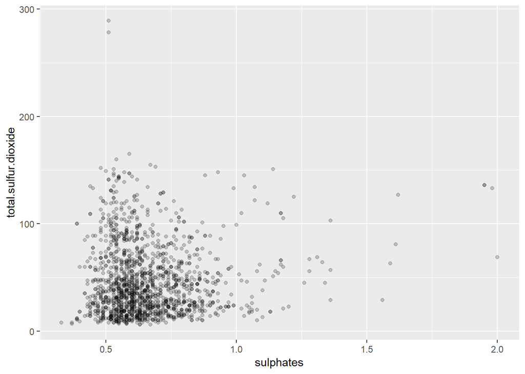

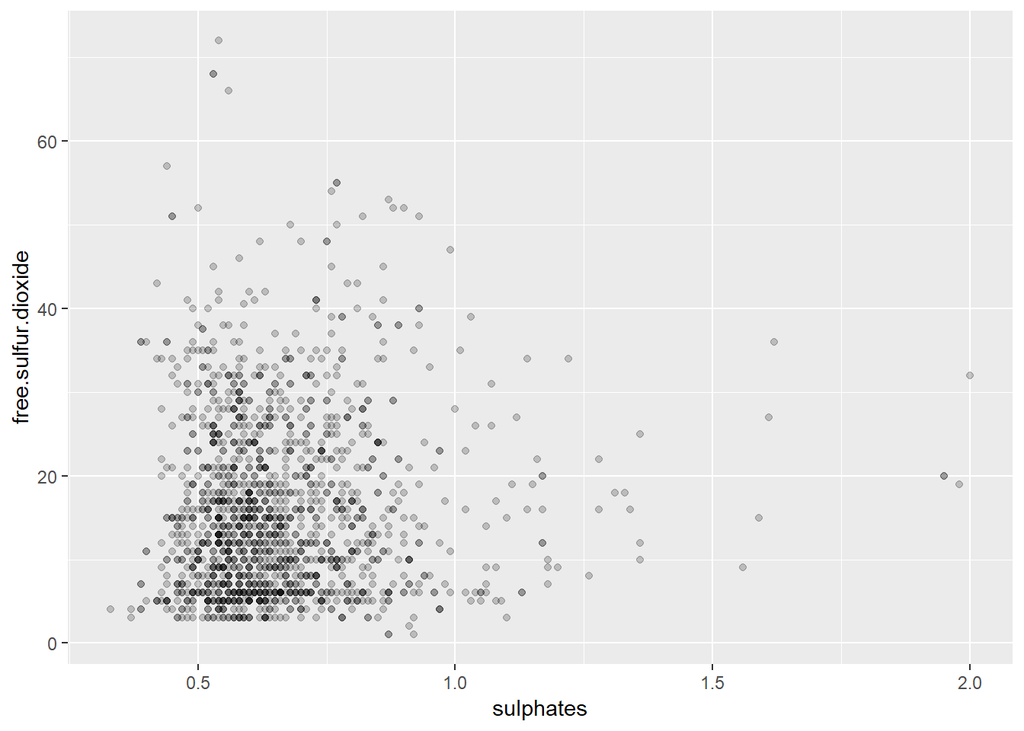

```
##
##  Pearson's product-moment correlation
##
## data:  total.sulfur.dioxide and sulphates
## t = 1.7178, df = 1597, p-value = 0.08602
## alternative hypothesis: true correlation is not equal to 0
## 95 percent confidence interval:
##  -0.006087119  0.091774762
## sample estimates:
##        cor
## 0.04294684
```

```
##
##  Pearson's product-moment correlation
##
## data:  free.sulfur.dioxide and sulphates
## t = 2.0671, df = 1597, p-value = 0.03888
## alternative hypothesis: true correlation is not equal to 0
## 95 percent confidence interval:
##  0.002643125 0.100424406
## sample estimates:
##        cor
## 0.05165757
```

The positive correlation between sulphate levels and sulfur dioxide appears to be very weak.

## Correlations with quality

```
##                             [,1]
## fixed.acidity         0.11408367
## volatile.acidity     -0.38064651
## citric.acid           0.21348091
## residual.sugar        0.03204817
## chlorides            -0.18992234
## free.sulfur.dioxide  -0.05690065
## total.sulfur.dioxide -0.19673508
## density              -0.17707407
## pH                   -0.04367193
## sulphates             0.37706020
## alcohol               0.47853169
```

# Bivariate Analysis

### Talk about some of the relationships you observed in this part of the investigation. How did the feature(s) of interest vary with other features in the dataset?

There seems to be a stronger correlation between wine quality and volatile acidity, citric acid, sulphates and alcohol content. The correlation coefficients seems to reflect the strength of the remaining variables.

```
##                             [,1]
## fixed.acidity         0.11408367
## volatile.acidity     -0.38064651
## citric.acid           0.21348091
## residual.sugar        0.03204817
## chlorides            -0.18992234
## free.sulfur.dioxide  -0.05690065
## total.sulfur.dioxide -0.19673508
## density              -0.17707407
## pH                   -0.04367193
## sulphates             0.37706020
## alcohol               0.47853169
```

### Did you observe any interesting relationships between the other features (not the main feature(s) of interest)?

Some of the interesting relationships between the other features observed were: the relation between the pH and acidity level,

the relation between the density and the alcohol and sugar content, and the relation between the residual sugar and alcohol level.

# Multivariate Plots Section

Looking at a correlation matrix:

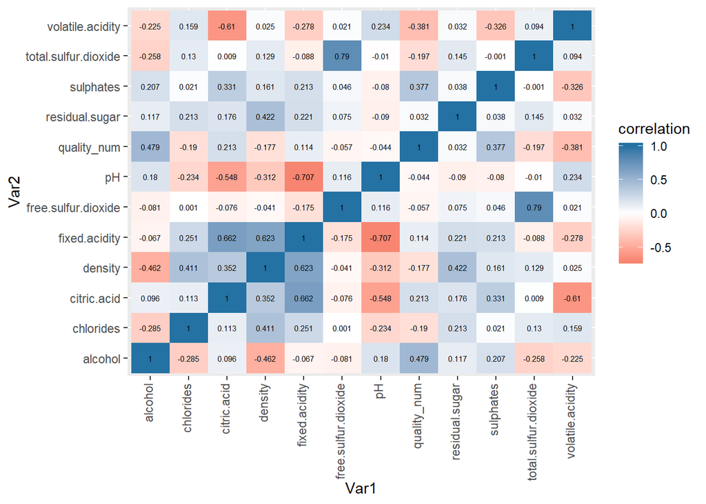

## Alcohol, volatile acidity and quality

# Quality seems to be strongly correlated to alcohol and volatile.acidity.

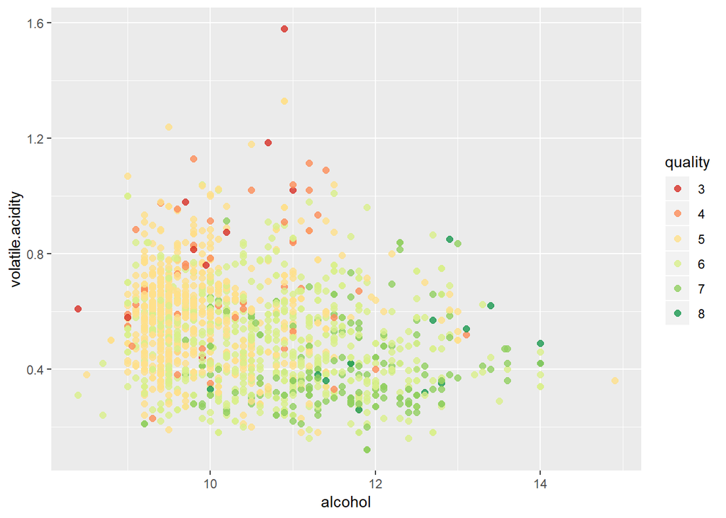

The worst quality wines appear to be at low alcohol and high volatile acidity while the middle quality wines (5 and 6) appear to spread around a bit everywhere.

## Acidity, pH, quality

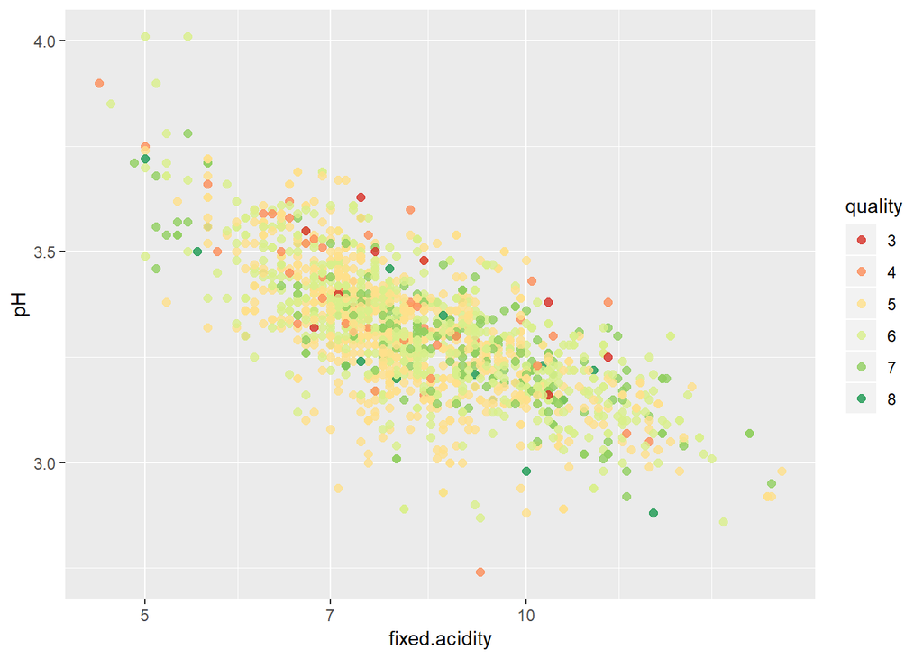

Quality distribution appears to show no pattern.

## Citric acid, alcohol, quality

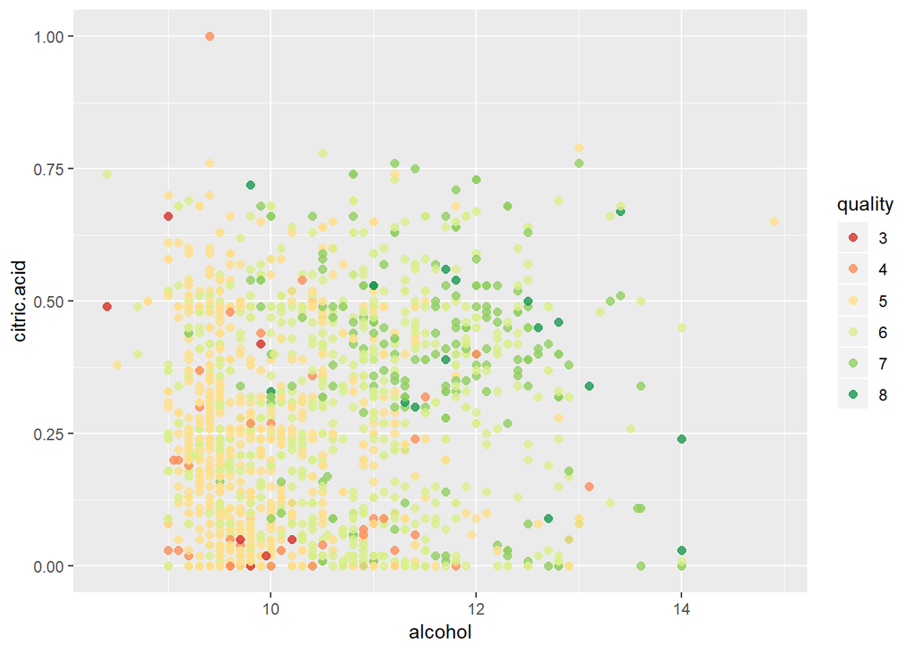

An increase in both citric acid and alcohol seems to correlate with higher quality wines. However, quality wines 5 appears to be on a wide range of citric acid levels at low alcohol content as well as high quality wines with low citric acid content.

## Alcohol and Sulphates

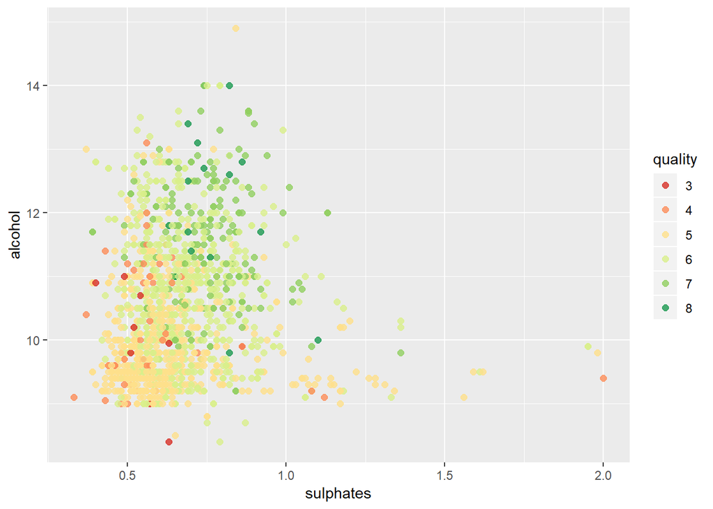

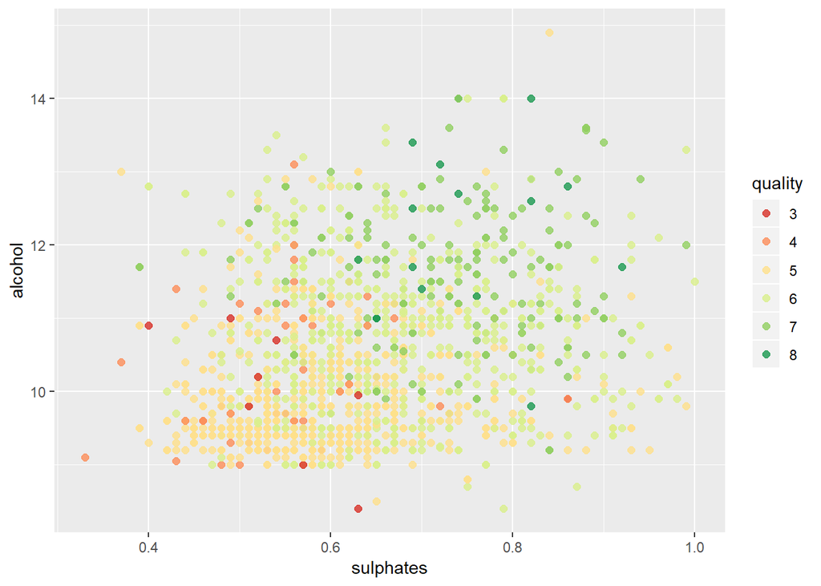

Alcohol and sulphates appear to have a positive correlation for sulphates ranges between 0 and 1. Combining higher alcohol with higher sulphates appears to be yield higher quality wines.

```
##
##  Pearson's product-moment correlation
##
## data:  alcohol and sulphates
## t = 3.7568, df = 1597, p-value = 0.0001783
## alternative hypothesis: true correlation is not equal to 0
## 95 percent confidence interval:
##  0.04477906 0.14196454
## sample estimates:
##        cor
## 0.09359475
```

# Multivariate Analysis

### Were there any interesting or surprising interactions between features?

### OPTIONAL: Did you create any models with your dataset? Discuss the strengths and limitations of your model.

# Final Plots and Summary

### Plot One

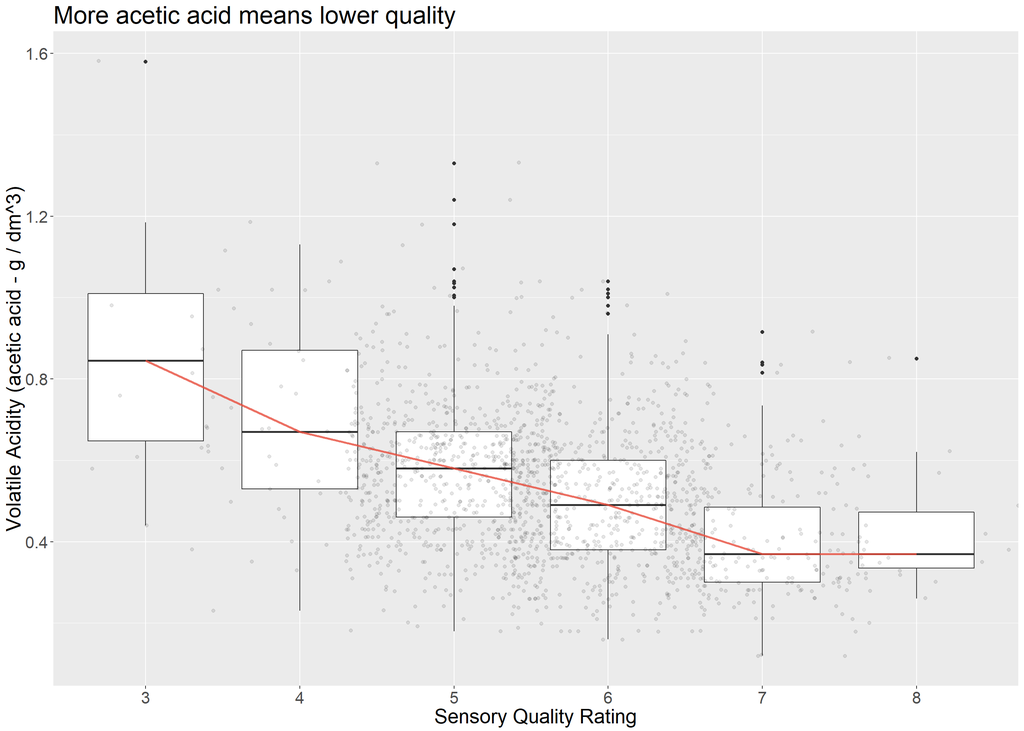

### Description One

The red line connecting the median values shows us the decreasing trend of volatile acidity with quality. Wines with lower volatile acidity content are rated higher in quality.

### Plot Two

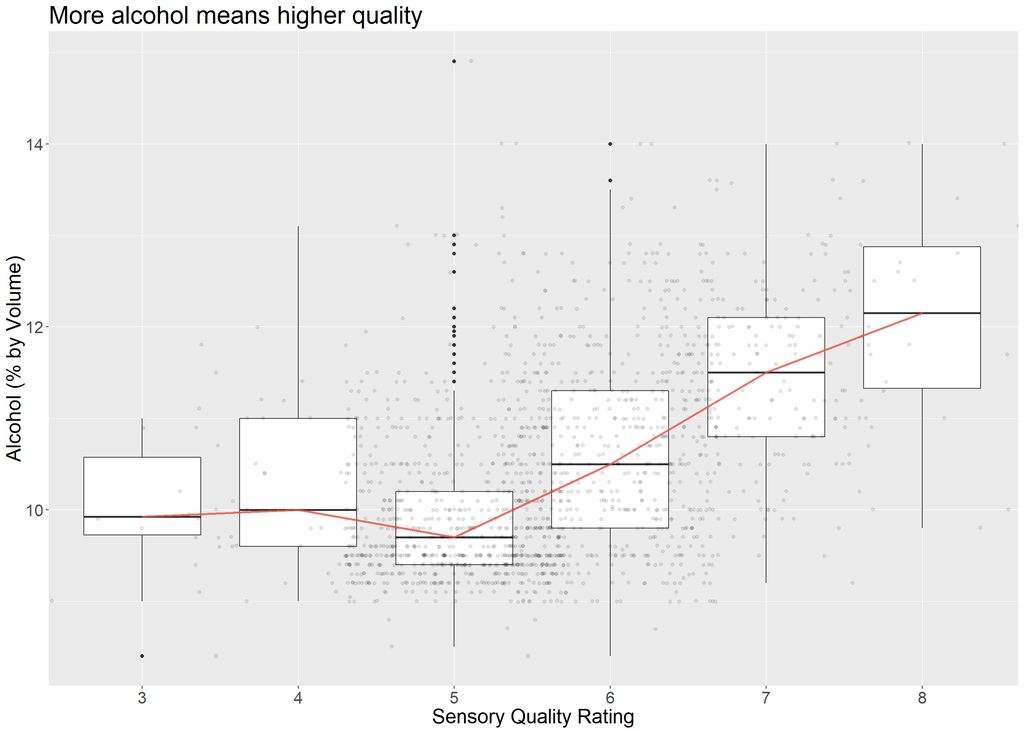

### Plot Three

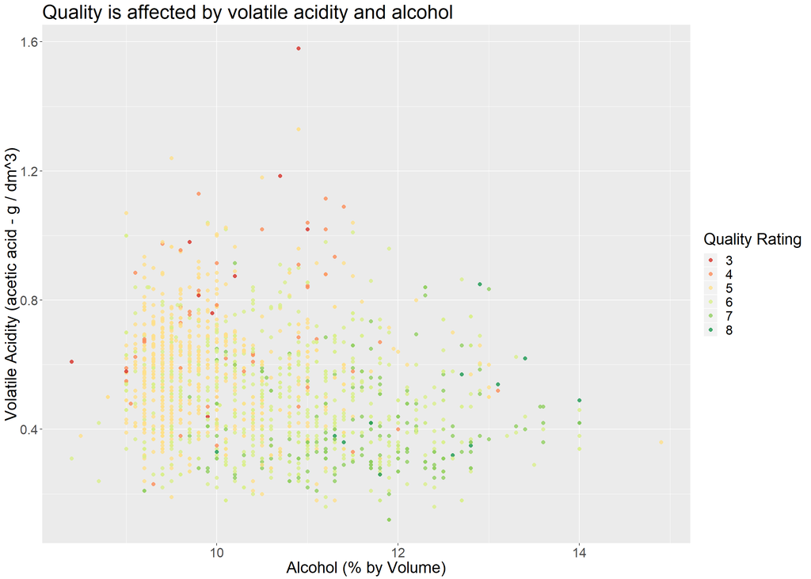

### Description Three

The combined effect of alcohol and volatile acidity on the quality seem to be big. High volatile acidity and low alcohol seem to have lower quality rating. Low volatile acidity and low alcohol seem to be in the middle quality rating categories. Low volatile acidity and high alcohol content seem to have higher quality rating.

# Reflection

This project allowed me to apply what I learn about R plotting to explore a real dataset. Since I chose a tidy data sets, no data cleaning or wrangling was needed. However, most of the red wines data points appeared to be at the middle levels than at the low and high ends. The first challenge was to explore what factors might affect the quality of red wine and what variables depend on each other. Plotting variables to predict red wine qualities was fairly accurate for average wines but extremely inaccurate for bad/excellent wines. Inaccurate prediction of bad and excellent wines may be due variables like citric acid, sulphates, volatile acidity being present in specific amounts.

The number one factor for determining an excellent red quality appeared to be Alcohol content.In order for alcohol to take over, however, Citric acid and sulphates needed to be in specific amounts. Large amounts of Volatile acidity seemed to make a wine bad under any circumstances.

Biases in the wine tasters’ preferences seemed to have been a weaknesses since expert wine tasters tend to look for different things in wine than the average person.

# References

Stattrek.com, (2016). *Patterns of Data in Statistics.* [online] Available at: http://stattrek.com/statistics/charts/data-patterns.aspx?tutorial=ap [Accessed 22 Feb. 2016].